# Final Project (Olympics)

Brian J Lesko

2022-07-29

# Initial Setup

```r
library(tidyverse)
library(readr)
```

Typical setup done

# Reading in the data

Data info: 120 years of Olympics data from a Kaggle: https://www.kaggle.com/heesoo37/120-years-of-olympic-history-athletes-and-results

Reading the data using the readr package

```r
athlete_events <- read_csv(
   file = 'athlete_events.csv',
   col_types = cols(ID = 'i', Age = 'i', Height = 'i', Year = 'i')
)

noc_regions <- read_csv('noc_regions.csv')
```

Lets take a look at the data that was just read.

```r
athlete_events
```

```
## # A tibble: 271,116 × 15
##       ID Name     Sex     Age Height Weight Team  NOC   Games  Year Season City
##    <int> <chr>    <chr> <int>  <int>  <dbl> <chr> <chr> <chr> <int> <chr>  <chr>
##  1     1 A Dijia… M        24    180     80 China CHN   1992…  1992 Summer Barc…
##  2     2 A Lamusi M        23    170     60 China CHN   2012…  2012 Summer Lond…
##  3     3 Gunnar … M        24     NA     NA Denm… DEN   1920…  1920 Summer Antw…
##  4     4 Edgar L… M        34     NA     NA Denm… DEN   1900…  1900 Summer Paris
##  5     5 Christi… F        21    185     82 Neth… NED   1988…  1988 Winter Calg…
##  6     5 Christi… F        21    185     82 Neth… NED   1988…  1988 Winter Calg…
##  7     5 Christi… F        25    185     82 Neth… NED   1992…  1992 Winter Albe…
##  8     5 Christi… F        25    185     82 Neth… NED   1992…  1992 Winter Albe…
##  9     5 Christi… F        27    185     82 Neth… NED   1994…  1994 Winter Lill…
## 10     5 Christi… F        27    185     82 Neth… NED   1994…  1994 Winter Lill…
## # … with 271,106 more rows, and 3 more variables: Sport <chr>, Event <chr>,
## #   Medal <chr>
```

```r
noc_regions
```

```
## # A tibble: 230 × 3
##    NOC   region      notes
##    <chr> <chr>       <chr>
##  1 AFG   Afghanistan <NA>
##  2 AHO   Curacao     Netherlands Antilles
##  3 ALB   Albania     <NA>
##  4 ALG   Algeria     <NA>
##  5 AND   Andorra     <NA>
##  6 ANG   Angola      <NA>
##  7 ANT   Antigua     Antigua and Barbuda
##  8 ANZ   Australia   Australasia
##  9 ARG   Argentina   <NA>
## 10 ARM   Armenia     <NA>
## # … with 220 more rows
```

*More info on athlete_events and noc_regions* noc_regions.csv: National organizing committee (NOC) regions for all the athletes in athlete_events.csv; see this Wikipedia page

athlete_events.csv: each row corresponds to an individual athlete competing in an individual Olympic event (athlete-events)

Lets Load some more data Data from Gapminder.org in the R package gapminder (see R4DS 25.2) (The install was only run once and then commented out)

```r
#install.packages("gapminder")
library(gapminder)
gapminder_unfiltered
```

```
## # A tibble: 3,313 × 6
##    country     continent  year lifeExp      pop gdpPercap
##    <fct>       <fct>     <int>   <dbl>    <int>     <dbl>
##  1 Afghanistan Asia       1952    28.8  8425333      779.
##  2 Afghanistan Asia       1957    30.3  9240934      821.
##  3 Afghanistan Asia       1962    32.0 10267083      853.
##  4 Afghanistan Asia       1967    34.0 11537966      836.
##  5 Afghanistan Asia       1972    36.1 13079460      740.
##  6 Afghanistan Asia       1977    38.4 14880372      786.
##  7 Afghanistan Asia       1982    39.9 12881816      978.
##  8 Afghanistan Asia       1987    40.8 13867957      852.
##  9 Afghanistan Asia       1992    41.7 16317921      649.
## 10 Afghanistan Asia       1997    41.8 22227415      635.
## # … with 3,303 more rows
```

#is this data somehow filtered? not sure

```r
gapminder
```

```
## # A tibble: 1,704 × 6
##    country     continent  year lifeExp      pop gdpPercap
##    <fct>       <fct>     <int>   <dbl>    <int>     <dbl>
##  1 Afghanistan Asia       1952    28.8  8425333      779.
##  2 Afghanistan Asia       1957    30.3  9240934      821.
##  3 Afghanistan Asia       1962    32.0 10267083      853.
##  4 Afghanistan Asia       1967    34.0 11537966      836.
##  5 Afghanistan Asia       1972    36.1 13079460      740.
##  6 Afghanistan Asia       1977    38.4 14880372      786.
##  7 Afghanistan Asia       1982    39.9 12881816      978.
##  8 Afghanistan Asia       1987    40.8 13867957      852.
##  9 Afghanistan Asia       1992    41.7 16317921      649.
## 10 Afghanistan Asia       1997    41.8 22227415      635.
## # … with 1,694 more rows
```

From the gapminder library

```r
country_codes
```

```
## # A tibble: 187 × 3
##    country     iso_alpha iso_num
##    <chr>       <chr>       <int>
##  1 Afghanistan AFG             4
##  2 Albania     ALB             8
##  3 Algeria     DZA            12
##  4 Angola      AGO            24
##  5 Argentina   ARG            32
##  6 Armenia     ARM            51
##  7 Aruba       ABW           533
##  8 Australia   AUS            36
##  9 Austria     AUT            40
## 10 Azerbaijan  AZE            31
## # … with 177 more rows
```

*Info on country_codes:* country_codes: ISO 3166-1 country codes for all the countries in gapminder and gapminder_unfiltered

One more data table to go: host_cities.csv this was downloaded from carmen as a txt file

```r
host_cities <- read_csv('host_cities.csv')
host_cities
```

```
## # A tibble: 42 × 2
##    city        country
##    <chr>       <chr>
##  1 Albertville France
##  2 Amsterdam   Netherlands
##  3 Antwerpen   Belgium
##  4 Athina      Greece
##  5 Atlanta     United States
##  6 Barcelona   Spain
##  7 Beijing     China
##  8 Berlin      Germany
##  9 Calgary     Canada
## 10 Chamonix    France
## # … with 32 more rows
```

*Info on: host_cities* host country for the cities in athlete_events.csv This file is on CarmenCanvas under the Final Project module.

# Converting Country Codes

Last part of Initial setup: Use the countrycode() function from the countrycode R package to convert the International Olympic Committee (IOC) country codes (‘ioc’) in the Olympics data to ISO 3166-1 country codes (‘iso3c’) used by gapminder. Note that some IOC codes may not match, because they are no longer used or there is no corresponding country in the Gapminder data.

*Install work*

```r
#install.packages("countrycode")
library(countrycode)
#countrycode()
```

*Chaging Gapminder_Unfiltered’s country column to iso3c code*

```r
gapminder_unfiltered
```

```
## # A tibble: 3,313 × 6
##    country     continent  year lifeExp      pop gdpPercap
##    <fct>       <fct>     <int>   <dbl>    <int>     <dbl>
##  1 Afghanistan Asia       1952    28.8  8425333      779.
##  2 Afghanistan Asia       1957    30.3  9240934      821.
##  3 Afghanistan Asia       1962    32.0 10267083      853.
##  4 Afghanistan Asia       1967    34.0 11537966      836.
##  5 Afghanistan Asia       1972    36.1 13079460      740.
##  6 Afghanistan Asia       1977    38.4 14880372      786.
##  7 Afghanistan Asia       1982    39.9 12881816      978.
##  8 Afghanistan Asia       1987    40.8 13867957      852.
##  9 Afghanistan Asia       1992    41.7 16317921      649.
## 10 Afghanistan Asia       1997    41.8 22227415      635.
## # … with 3,303 more rows
```

```r
#this will return a vector to replace the country column in gapminder_unfiltered. Lets store it to use in a mutate
country_codes <- countrycode(sourcevar=gapminder_unfiltered$country, origin="country.name", destination="iso3c", nomatch=T)
#for now, lets add a number at the end for each time we modify a data frame
gapminder_unfiltered1 <- gapminder_unfiltered %>%
  mutate(country=country_codes)

gapminder_unfiltered1
```

```
## # A tibble: 3,313 × 6
##    country continent  year lifeExp      pop gdpPercap
##    <chr>   <fct>     <int>   <dbl>    <int>     <dbl>
##  1 AFG     Asia       1952    28.8  8425333      779.
##  2 AFG     Asia       1957    30.3  9240934      821.
##  3 AFG     Asia       1962    32.0 10267083      853.
##  4 AFG     Asia       1967    34.0 11537966      836.
##  5 AFG     Asia       1972    36.1 13079460      740.
##  6 AFG     Asia       1977    38.4 14880372      786.
##  7 AFG     Asia       1982    39.9 12881816      978.
##  8 AFG     Asia       1987    40.8 13867957      852.
##  9 AFG     Asia       1992    41.7 16317921      649.
## 10 AFG     Asia       1997    41.8 22227415      635.
## # … with 3,303 more rows
```

*Changing athlete_events’ country code column to iso3c code* note: is it team or NOC? NOC: as the directions state International olympic committee NOC - National Olympic Committee 3-letter code Team - Team name

```r
glimpse(athlete_events)
```

```
## Rows: 271,116
## Columns: 15
## $ ID     <int> 1, 2, 3, 4, 5, 5, 5, 5, 5, 5, 6, 6, 6, 6, 6, 6, 6, 6, 7, 7, 7, …
## $ Name   <chr> "A Dijiang", "A Lamusi", "Gunnar Nielsen Aaby", "Edgar Lindenau…
## $ Sex    <chr> "M", "M", "M", "M", "F", "F", "F", "F", "F", "F", "M", "M", "M"…
## $ Age    <int> 24, 23, 24, 34, 21, 21, 25, 25, 27, 27, 31, 31, 31, 31, 33, 33,…
## $ Height <int> 180, 170, NA, NA, 185, 185, 185, 185, 185, 185, 188, 188, 188, …
## $ Weight <dbl> 80, 60, NA, NA, 82, 82, 82, 82, 82, 82, 75, 75, 75, 75, 75, 75,…
## $ Team   <chr> "China", "China", "Denmark", "Denmark/Sweden", "Netherlands", "…
## $ NOC    <chr> "CHN", "CHN", "DEN", "DEN", "NED", "NED", "NED", "NED", "NED", …
## $ Games  <chr> "1992 Summer", "2012 Summer", "1920 Summer", "1900 Summer", "19…
## $ Year   <int> 1992, 2012, 1920, 1900, 1988, 1988, 1992, 1992, 1994, 1994, 199…
## $ Season <chr> "Summer", "Summer", "Summer", "Summer", "Winter", "Winter", "Wi…
## $ City   <chr> "Barcelona", "London", "Antwerpen", "Paris", "Calgary", "Calgar…
## $ Sport  <chr> "Basketball", "Judo", "Football", "Tug-Of-War", "Speed Skating"…
## $ Event  <chr> "Basketball Men's Basketball", "Judo Men's Extra-Lightweight", …
## $ Medal  <chr> NA, NA, NA, "Gold", NA, NA, NA, NA, NA, NA, NA, NA, NA, NA, NA,…
```

```r
#noc_regions

#again, a column of contry codes converted to iso3c standard (for use in a mutate)
country_codes2 <- countrycode(sourcevar=athlete_events$NOC, origin="ioc", destination="iso3c", nomatch=NA)
#again, lets add a number at the end for each time we modify a data frame
athlete_events1 <- athlete_events %>%
  mutate(country=country_codes2)

glimpse(athlete_events1)
```

```
## Rows: 271,116
## Columns: 16
## $ ID      <int> 1, 2, 3, 4, 5, 5, 5, 5, 5, 5, 6, 6, 6, 6, 6, 6, 6, 6, 7, 7, 7,…
## $ Name    <chr> "A Dijiang", "A Lamusi", "Gunnar Nielsen Aaby", "Edgar Lindena…
## $ Sex     <chr> "M", "M", "M", "M", "F", "F", "F", "F", "F", "F", "M", "M", "M…
## $ Age     <int> 24, 23, 24, 34, 21, 21, 25, 25, 27, 27, 31, 31, 31, 31, 33, 33…
## $ Height  <int> 180, 170, NA, NA, 185, 185, 185, 185, 185, 185, 188, 188, 188,…
## $ Weight  <dbl> 80, 60, NA, NA, 82, 82, 82, 82, 82, 82, 75, 75, 75, 75, 75, 75…
## $ Team    <chr> "China", "China", "Denmark", "Denmark/Sweden", "Netherlands", …
## $ NOC     <chr> "CHN", "CHN", "DEN", "DEN", "NED", "NED", "NED", "NED", "NED",…
## $ Games   <chr> "1992 Summer", "2012 Summer", "1920 Summer", "1900 Summer", "1…
## $ Year    <int> 1992, 2012, 1920, 1900, 1988, 1988, 1992, 1992, 1994, 1994, 19…
## $ Season  <chr> "Summer", "Summer", "Summer", "Summer", "Winter", "Winter", "W…
## $ City    <chr> "Barcelona", "London", "Antwerpen", "Paris", "Calgary", "Calga…
## $ Sport   <chr> "Basketball", "Judo", "Football", "Tug-Of-War", "Speed Skating…
## $ Event   <chr> "Basketball Men's Basketball", "Judo Men's Extra-Lightweight",…
## $ Medal   <chr> NA, NA, NA, "Gold", NA, NA, NA, NA, NA, NA, NA, NA, NA, NA, NA…
## $ country <chr> "CHN", "CHN", "DNK", "DNK", "NLD", "NLD", "NLD", "NLD", "NLD",…
```

*adding a column to noc_regions with the iso3c country code based on NOC*

```r
noc_regions
```

```
## # A tibble: 230 × 3
##    NOC   region      notes
##    <chr> <chr>       <chr>
##  1 AFG   Afghanistan <NA>
##  2 AHO   Curacao     Netherlands Antilles
##  3 ALB   Albania     <NA>
##  4 ALG   Algeria     <NA>
##  5 AND   Andorra     <NA>
##  6 ANG   Angola      <NA>
##  7 ANT   Antigua     Antigua and Barbuda
##  8 ANZ   Australia   Australasia
##  9 ARG   Argentina   <NA>
## 10 ARM   Armenia     <NA>
## # … with 220 more rows
```

```r
#again, a column of contry codes converted to iso3c standard (for use in a mutate)
country_codes3 <- countrycode(sourcevar=noc_regions$NOC, origin="ioc", destination="iso3c", nomatch=NA)
#again, lets add a number at the end for each time we modify a data frame
noc_regions1 <- noc_regions %>%
  mutate(country=country_codes3) %>%
  select(NOC,country,region,notes)

noc_regions1
```

```
## # A tibble: 230 × 4
##    NOC   country region      notes
##    <chr> <chr>   <chr>       <chr>
##  1 AFG   AFG     Afghanistan <NA>
##  2 AHO   <NA>    Curacao     Netherlands Antilles
##  3 ALB   ALB     Albania     <NA>
##  4 ALG   DZA     Algeria     <NA>
##  5 AND   AND     Andorra     <NA>
##  6 ANG   AGO     Angola      <NA>
##  7 ANT   ATG     Antigua     Antigua and Barbuda
##  8 ANZ   <NA>    Australia   Australasia
##  9 ARG   ARG     Argentina   <NA>
## 10 ARM   ARM     Armenia     <NA>
## # … with 220 more rows
```

# **Question 1**

**Is there a relationship between a country’s GDP and the number of athletes it sends to an Olympic games?** Consider making a scatterplot where each point shows the number of atheltes and GDP of a single country (or NOC) during a single game. You may also want to **consider summer and winter games separately** or separate periods of time.

To answer this question you will at least need to **construct a table containing both numbers of athletes for each country, olympic games, and the country’s GDP.** Note that **socioeconomic data does not cover the entire 120 years of Olympics and it does not cover all countries that have participated**, so you can **restrict these questions to the available data**. You will have to think about how to **join the gapminder data with the Olympics data**. You will also have to think about how to **count the number of athletes, because some athletes participate in more than one event**

Hint: Consider **nonlinear scales with ggplot2, e.g. scale_x_log10() and normalizing by population.**

**Number of athletes sent by country each game**

```r
athlete_events1
```

```
## # A tibble: 271,116 × 16
##       ID Name     Sex     Age Height Weight Team  NOC   Games  Year Season City
##    <int> <chr>    <chr> <int>  <int>  <dbl> <chr> <chr> <chr> <int> <chr>  <chr>
##  1     1 A Dijia… M        24    180     80 China CHN   1992…  1992 Summer Barc…
##  2     2 A Lamusi M        23    170     60 China CHN   2012…  2012 Summer Lond…
##  3     3 Gunnar … M        24     NA     NA Denm… DEN   1920…  1920 Summer Antw…
##  4     4 Edgar L… M        34     NA     NA Denm… DEN   1900…  1900 Summer Paris
##  5     5 Christi… F        21    185     82 Neth… NED   1988…  1988 Winter Calg…
##  6     5 Christi… F        21    185     82 Neth… NED   1988…  1988 Winter Calg…
##  7     5 Christi… F        25    185     82 Neth… NED   1992…  1992 Winter Albe…
##  8     5 Christi… F        25    185     82 Neth… NED   1992…  1992 Winter Albe…
##  9     5 Christi… F        27    185     82 Neth… NED   1994…  1994 Winter Lill…
## 10     5 Christi… F        27    185     82 Neth… NED   1994…  1994 Winter Lill…
## # … with 271,106 more rows, and 4 more variables: Sport <chr>, Event <chr>,
## #   Medal <chr>, country <chr>
```

```r
athlete_events1 %>%
  mutate(row_number=row_number()) %>%
  count(ID,country,Games,Event,row_number) %>% #had to use a surrogate key
  filter(n>1)
```

```
## # A tibble: 0 × 6
## # … with 6 variables: ID <int>, country <chr>, Games <chr>, Event <chr>,
## #   row_number <int>, n <int>
```

```r
athletes_sent <- athlete_events1 %>%
  mutate(row_number=row_number()) %>%
  count(ID,country,Games,Event,row_number,Year) %>%#had to use a surrogate key
  count(country,Games,Year) %>%
  arrange(Games,country)
athletes_sent
```

```
## # A tibble: 3,696 × 4
##    country Games        Year     n
##    <chr>   <chr>       <int> <int>
##  1 AUS     1896 Summer  1896     5
##  2 AUT     1896 Summer  1896     8
##  3 CHE     1896 Summer  1896     8
##  4 DEU     1896 Summer  1896    94
##  5 DNK     1896 Summer  1896    15
##  6 FRA     1896 Summer  1896    26
##  7 GBR     1896 Summer  1896    25
##  8 GRC     1896 Summer  1896   148
##  9 HUN     1896 Summer  1896    18
## 10 ITA     1896 Summer  1896     1
## # … with 3,686 more rows
```

**I Now want to extract summer and winter from the games column**

```r
athletes_sent_summer <- athletes_sent %>%
  mutate(time_of_year = substr(Games,6,11)) %>%
  filter(time_of_year=="Summer") %>%
  mutate(athletes_sent=n) %>%
  arrange(Year,country) %>%
  select(country,Year,athletes_sent,time_of_year)
athletes_sent_summer
```

```
## # A tibble: 2,722 × 4
##    country  Year athletes_sent time_of_year
##    <chr>   <int>         <int> <chr>
##  1 AUS      1896             5 Summer
##  2 AUT      1896             8 Summer
##  3 CHE      1896             8 Summer
##  4 DEU      1896            94 Summer
##  5 DNK      1896            15 Summer
##  6 FRA      1896            26 Summer
##  7 GBR      1896            25 Summer
##  8 GRC      1896           148 Summer
##  9 HUN      1896            18 Summer
## 10 ITA      1896             1 Summer
## # … with 2,712 more rows
```

```r
athletes_sent_winter <- athletes_sent %>%
  mutate(time_of_year = substr(Games,6,11)) %>%
  filter(time_of_year=="Winter") %>%
  mutate(athletes_sent=n) %>%
  arrange(Year,country) %>%
  select(country,Year,athletes_sent,time_of_year)
athletes_sent_winter
```

```
## # A tibble: 974 × 4
##    country  Year athletes_sent time_of_year
##    <chr>   <int>         <int> <chr>
##  1 AUS      1924             1 Winter
##  2 AUT      1924             4 Winter
##  3 BEL      1924            32 Winter
##  4 CAN      1924            17 Winter
##  5 CHE      1924            39 Winter
##  6 FIN      1924            33 Winter
##  7 FRA      1924            68 Winter
##  8 GBR      1924            50 Winter
##  9 HUN      1924             6 Winter
## 10 IND      1924             7 Winter
## # … with 964 more rows
```

**joining GDP to the athletes sent by country for Winter and Summer**

```r
gapminder_unfiltered1
```

```
## # A tibble: 3,313 × 6
##    country continent  year lifeExp      pop gdpPercap
##    <chr>   <fct>     <int>   <dbl>    <int>     <dbl>
##  1 AFG     Asia       1952    28.8  8425333      779.
##  2 AFG     Asia       1957    30.3  9240934      821.
##  3 AFG     Asia       1962    32.0 10267083      853.
##  4 AFG     Asia       1967    34.0 11537966      836.
##  5 AFG     Asia       1972    36.1 13079460      740.
##  6 AFG     Asia       1977    38.4 14880372      786.
##  7 AFG     Asia       1982    39.9 12881816      978.
##  8 AFG     Asia       1987    40.8 13867957      852.
##  9 AFG     Asia       1992    41.7 16317921      649.
## 10 AFG     Asia       1997    41.8 22227415      635.
## # … with 3,303 more rows
```

```r
#making sure country and year are a key
gapminder_unfiltered1 %>%
  select(country,year,gdpPercap) %>%
  count(country,year) %>%
  filter(n>1)
```

```
## # A tibble: 0 × 3
## # … with 3 variables: country <chr>, year <int>, n <int>
```

```r
#I want to use a mutating join to add the GDP column to the previous table made

athletes_sent_summer1 <- athletes_sent_summer %>%
 left_join(gapminder_unfiltered1,by=c("country"="country","Year"="year")) %>%
  select(country,Year,athletes_sent,gdpPercap,time_of_year,pop) %>%
  arrange(Year,country)

athletes_sent_summer1
```

```
## # A tibble: 2,722 × 6
##    country  Year athletes_sent gdpPercap time_of_year   pop
##    <chr>   <int>         <int>     <dbl> <chr>        <int>
##  1 AUS      1896             5        NA Summer          NA
##  2 AUT      1896             8        NA Summer          NA
##  3 CHE      1896             8        NA Summer          NA
##  4 DEU      1896            94        NA Summer          NA
##  5 DNK      1896            15        NA Summer          NA
##  6 FRA      1896            26        NA Summer          NA
##  7 GBR      1896            25        NA Summer          NA
##  8 GRC      1896           148        NA Summer          NA
##  9 HUN      1896            18        NA Summer          NA
## 10 ITA      1896             1        NA Summer          NA
## # … with 2,712 more rows
```

```r
athletes_sent_winter1 <- athletes_sent_winter %>%
  left_join(gapminder_unfiltered1,by=c("country"="country","Year"="year")) %>%
  select(country,Year,athletes_sent,gdpPercap,time_of_year,pop) %>%
  arrange(Year,country)

athletes_sent_winter1
```

```
## # A tibble: 974 × 6
##    country  Year athletes_sent gdpPercap time_of_year   pop
##    <chr>   <int>         <int>     <dbl> <chr>        <int>
##  1 AUS      1924             1        NA Winter          NA
##  2 AUT      1924             4        NA Winter          NA
##  3 BEL      1924            32        NA Winter          NA
##  4 CAN      1924            17        NA Winter          NA
##  5 CHE      1924            39        NA Winter          NA
##  6 FIN      1924            33        NA Winter          NA
##  7 FRA      1924            68        NA Winter          NA
##  8 GBR      1924            50        NA Winter          NA
##  9 HUN      1924             6        NA Winter          NA
## 10 IND      1924             7        NA Winter          NA
## # … with 964 more rows
```

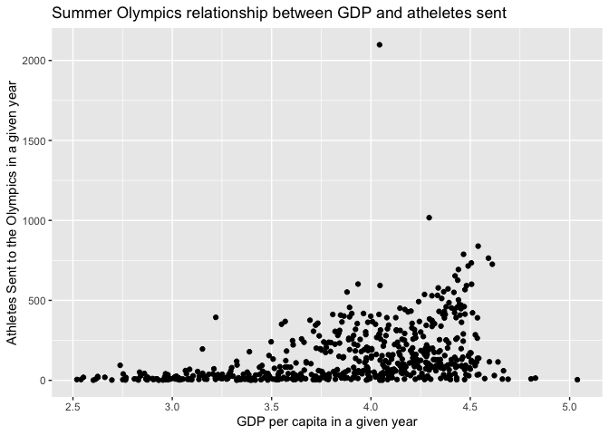

```r
ggplot(athletes_sent_summer1,mapping=aes(x=log10(gdpPercap),y=(athletes_sent))) +
  geom_point() +
  labs(y="Athletes Sent to the Olympics in a given year",x="GDP per capita in a given year",title="Summer Olympics relationship between GDP and atheletes sent")
```

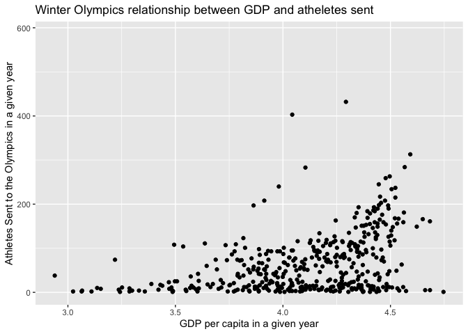

```r
ggplot(athletes_sent_winter1,mapping=aes(x=log10(gdpPercap),y=(athletes_sent))) +
  geom_point() +
  labs(y="Athletes Sent to the Olympics in a given year",x="GDP per capita in a given year",title="Winter Olympics relationship between GDP and atheletes sent")
```

There seems to be a positive relationship between GDP per capita and athletes sent to the olympic games for both summer and winter olympics. when an athelete competes more than once (in different events), they are counted as multiple athletes

# **Question 2**

Question 2 Is there a host country effect on the number of medals? In other words, do countries earn more medals when they host an Olympic games compared to when they do not host an Olympic games? To answer this question you will have to count the number of medals that a country wins in each game, being careful about how you handle team events. You will also have to join the Olympics data with the host_cities data to determine the country of the host city. You will want to think about numbers or possibly rates, and how to compare a country’s winnings when it hosts a game versus when it has not hosted a game.

```r
athlete_events1
```

```
## # A tibble: 271,116 × 16
##       ID Name     Sex     Age Height Weight Team  NOC   Games  Year Season City
##    <int> <chr>    <chr> <int>  <int>  <dbl> <chr> <chr> <chr> <int> <chr>  <chr>
##  1     1 A Dijia… M        24    180     80 China CHN   1992…  1992 Summer Barc…
##  2     2 A Lamusi M        23    170     60 China CHN   2012…  2012 Summer Lond…
##  3     3 Gunnar … M        24     NA     NA Denm… DEN   1920…  1920 Summer Antw…
##  4     4 Edgar L… M        34     NA     NA Denm… DEN   1900…  1900 Summer Paris
##  5     5 Christi… F        21    185     82 Neth… NED   1988…  1988 Winter Calg…
##  6     5 Christi… F        21    185     82 Neth… NED   1988…  1988 Winter Calg…
##  7     5 Christi… F        25    185     82 Neth… NED   1992…  1992 Winter Albe…
##  8     5 Christi… F        25    185     82 Neth… NED   1992…  1992 Winter Albe…
##  9     5 Christi… F        27    185     82 Neth… NED   1994…  1994 Winter Lill…
## 10     5 Christi… F        27    185     82 Neth… NED   1994…  1994 Winter Lill…
## # … with 271,106 more rows, and 4 more variables: Sport <chr>, Event <chr>,
## #   Medal <chr>, country <chr>
```

```r
medals <- athlete_events1 %>%
  mutate(is_medal=!is.na(Medal)) %>%
  #to handle team events
  group_by(country,Year,Season,Event,Medal) %>%
  mutate(number_in_event=n())%>% #if this is >1, **WHILE there is a won medal**, this indicates either a team win for the event, or a tie between two contestants from the same country, in either case, I will count this as only 1 gold medal for said country in that olympic season.
  mutate(multiple_entries = number_in_event>1) %>%
  mutate(team_win = (multiple_entries & is_medal) )%>% #(&& is_medal needs to be true) refrence above comment
  ungroup() %>%
  #select(country,Year,Season,team_win,is_medal,Event,everything()) %>%
  arrange(desc(team_win),country,Year,Season) %>%
  select(country,Year,Season,team_win,is_medal,Event,City) %>%
  group_by(country,Year,Season,City) %>%
  distinct() %>% #gets rid of duplicate rows
  summarise(medal_total=sum(is_medal))%>%# %of medals won based off event entries in that game season
  rename(host_city=City)


medals
```

```
## # A tibble: 3,720 × 5
## # Groups:   country, Year, Season [3,696]
##    country  Year Season host_city      medal_total
##    <chr>   <int> <chr>  <chr>                <int>
##  1 ABW      1988 Summer Seoul                    0
##  2 ABW      1992 Summer Barcelona                0
##  3 ABW      1996 Summer Atlanta                  0
##  4 ABW      2000 Summer Sydney                   0
##  5 ABW      2004 Summer Athina                   0
##  6 ABW      2008 Summer Beijing                  0
##  7 ABW      2012 Summer London                   0
##  8 ABW      2016 Summer Rio de Janeiro           0
##  9 AFG      1936 Summer Berlin                   0
## 10 AFG      1948 Summer London                   0
## # … with 3,710 more rows
```

**Now to prep the location data for merging**

```r
host_cities1 <- host_cities %>%
  rename(host_city=city) %>%
  rename(host_country=country)
host_cities1
```

```
## # A tibble: 42 × 2
##    host_city   host_country
##    <chr>       <chr>
##  1 Albertville France
##  2 Amsterdam   Netherlands
##  3 Antwerpen   Belgium
##  4 Athina      Greece
##  5 Atlanta     United States
##  6 Barcelona   Spain
##  7 Beijing     China
##  8 Berlin      Germany
##  9 Calgary     Canada
## 10 Chamonix    France
## # … with 32 more rows
```

```r
country_codes4 <- countrycode(sourcevar=host_cities1$host_country, origin="country.name", destination="iso3c", nomatch=NA)

host_cities2 <- host_cities1 %>%
  mutate(host_country=country_codes4)

hostAndMedals <- medals %>%
  left_join(host_cities2,by=c("host_city")) %>%
  select(country,Year,Season,medal_total,host_city,host_country)

hostAndMedals
```

```
## # A tibble: 3,720 × 6
## # Groups:   country, Year, Season [3,696]
##    country  Year Season medal_total host_city      host_country
##    <chr>   <int> <chr>        <int> <chr>          <chr>
##  1 ABW      1988 Summer           0 Seoul          KOR
##  2 ABW      1992 Summer           0 Barcelona      ESP
##  3 ABW      1996 Summer           0 Atlanta        USA
##  4 ABW      2000 Summer           0 Sydney         AUS
##  5 ABW      2004 Summer           0 Athina         GRC
##  6 ABW      2008 Summer           0 Beijing        CHN
##  7 ABW      2012 Summer           0 London         GBR
##  8 ABW      2016 Summer           0 Rio de Janeiro BRA
##  9 AFG      1936 Summer           0 Berlin         DEU
## 10 AFG      1948 Summer           0 London         GBR
## # … with 3,710 more rows
```

**Now that the two tables are joined, its time for more data organization**

```r
hostAndMedals %>%
  mutate(is_host = (country==host_country)) %>%
  group_by(country,is_host) %>%
  summarise(medal_total2=sum(medal_total)) %>%
  arrange(country,is_host) %>%
  ungroup() %>%
  group_by(is_host) %>%
  summarise(avg_medal_count=mean(medal_total2))
```

```
## # A tibble: 3 × 2
##   is_host avg_medal_count
##   <lgl>             <dbl>
## 1 FALSE              64.6
## 2 TRUE               66.8
## 3 NA               1625
```

# **Question 2 ATTEMPT 2**

Lets first merge the relevant data into one tibble and do some reorganization to make the data easier to work with

```r
athlete_events2 <- athlete_events1 %>%
  rename(host_city=City)

host_cities1 <- host_cities %>%
  rename(host_city=city) %>%
  rename(host_country=country)
country_codes4 <- countrycode(sourcevar=host_cities1$host_country, origin="country.name", destination="iso3c", nomatch=NA)
host_cities2 <- host_cities1 %>%
  mutate(host_country=country_codes4)

host_cities2
```

```
## # A tibble: 42 × 2
##    host_city   host_country
##    <chr>       <chr>
##  1 Albertville FRA
##  2 Amsterdam   NLD
##  3 Antwerpen   BEL
##  4 Athina      GRC
##  5 Atlanta     USA
##  6 Barcelona   ESP
##  7 Beijing     CHN
##  8 Berlin      DEU
##  9 Calgary     CAN
## 10 Chamonix    FRA
## # … with 32 more rows
```

```r
athlete_events2
```

```
## # A tibble: 271,116 × 16
##       ID Name           Sex     Age Height Weight Team  NOC   Games  Year Season
##    <int> <chr>          <chr> <int>  <int>  <dbl> <chr> <chr> <chr> <int> <chr>
##  1     1 A Dijiang      M        24    180     80 China CHN   1992…  1992 Summer
##  2     2 A Lamusi       M        23    170     60 China CHN   2012…  2012 Summer
##  3     3 Gunnar Nielse… M        24     NA     NA Denm… DEN   1920…  1920 Summer
##  4     4 Edgar Lindena… M        34     NA     NA Denm… DEN   1900…  1900 Summer
##  5     5 Christine Jac… F        21    185     82 Neth… NED   1988…  1988 Winter
##  6     5 Christine Jac… F        21    185     82 Neth… NED   1988…  1988 Winter
##  7     5 Christine Jac… F        25    185     82 Neth… NED   1992…  1992 Winter
##  8     5 Christine Jac… F        25    185     82 Neth… NED   1992…  1992 Winter
##  9     5 Christine Jac… F        27    185     82 Neth… NED   1994…  1994 Winter
## 10     5 Christine Jac… F        27    185     82 Neth… NED   1994…  1994 Winter
## # … with 271,106 more rows, and 5 more variables: host_city <chr>, Sport <chr>,
## #   Event <chr>, Medal <chr>, country <chr>
```

```r
joined <- athlete_events2 %>%
  left_join(host_cities2,by=c("host_city")) %>%
  select(country,Year,Season,host_country,Medal,Event,everything())

joined #this new tibble is athlete_events with the host country data now added
```

```
## # A tibble: 271,116 × 17
##    country  Year Season host_country Medal Event     ID Name  Sex     Age Height
##    <chr>   <int> <chr>  <chr>        <chr> <chr>  <int> <chr> <chr> <int>  <int>
##  1 CHN      1992 Summer ESP          <NA>  Baske…     1 A Di… M        24    180
##  2 CHN      2012 Summer GBR          <NA>  Judo …     2 A La… M        23    170
##  3 DNK      1920 Summer BEL          <NA>  Footb…     3 Gunn… M        24     NA
##  4 DNK      1900 Summer FRA          Gold  Tug-O…     4 Edga… M        34     NA
##  5 NLD      1988 Winter CAN          <NA>  Speed…     5 Chri… F        21    185
##  6 NLD      1988 Winter CAN          <NA>  Speed…     5 Chri… F        21    185
##  7 NLD      1992 Winter FRA          <NA>  Speed…     5 Chri… F        25    185
##  8 NLD      1992 Winter FRA          <NA>  Speed…     5 Chri… F        25    185
##  9 NLD      1994 Winter NOR          <NA>  Speed…     5 Chri… F        27    185
## 10 NLD      1994 Winter NOR          <NA>  Speed…     5 Chri… F        27    185
## # … with 271,106 more rows, and 6 more variables: Weight <dbl>, Team <chr>,
## #   NOC <chr>, Games <chr>, host_city <chr>, Sport <chr>
```

Lets count the number of medals a country gets for every Olympics game Lets also count team wins as a single medal as well as ties among contestants from the same country as a single medal

```r
Medals <- joined %>%
  mutate(won_medal = !is.na(Medal)) %>%
  mutate(is_host = (country==host_country)) %>%
  #The next three lines account for team wins and ties among same country contestants
  #it also eliminates multiple losing contestants from the same country, but that is okay
  #because we are only counting wins in this data frame
  select(country,Year,Season,Event,Medal) %>%
  group_by(country,Year,Season,Event,Medal) %>%
  distinct() %>%
  ungroup() %>%
  #now we can tally the wins
  filter(!is.na(Medal)) %>%
  group_by(country,Year,Season) %>%
  summarise(medal_count=n())
  #here I checked a few rows:
#in 2016 Australia won 29 medals, this agrees with my data
#in 2014 Australia won 3 medals, this also agrees
#in 2012 Australia won 35 medals, this also agrees with my data
#I am now more confident that I have handled ties and team wins appropriately

Medals
```

```
## # A tibble: 1,592 × 4
## # Groups:   country, Year [1,396]
##    country  Year Season medal_count
##    <chr>   <int> <chr>        <int>
##  1 AFG      2008 Summer           1
##  2 AFG      2012 Summer           1
##  3 ARE      2004 Summer           1
##  4 ARE      2016 Summer           1
##  5 ARG      1924 Summer           6
##  6 ARG      1928 Summer           7
##  7 ARG      1932 Summer           4
##  8 ARG      1936 Summer           7
##  9 ARG      1948 Summer           7
## 10 ARG      1952 Summer           5
## # … with 1,582 more rows
```

Now lets add back in the data about the host country

```r
#a dataframe with only the data about the host countries in is03c
host_countries <- joined %>%
  select(Year,Season,host_country) %>%
  distinct()
host_countries
```

```
## # A tibble: 52 × 3
##     Year Season host_country
##    <int> <chr>  <chr>
##  1  1992 Summer ESP
##  2  2012 Summer GBR
##  3  1920 Summer BEL
##  4  1900 Summer FRA
##  5  1988 Winter CAN
##  6  1992 Winter FRA
##  7  1994 Winter NOR
##  8  1932 Summer USA
##  9  2002 Winter USA
## 10  1952 Summer FIN
## # … with 42 more rows
```

```r
#note: there have been 53 olympics, but there is only 52 entries here -  this could be investigated further

#now lets combine this with the Medals data frame organized in the last code block
Medals_hosts <- Medals %>%
  left_join(host_countries,by=c("Year"="Year","Season"="Season")) %>%
  filter(!is.na(country)) #this gets rid of countries missing from the iso3c list
Medals_hosts
```

```
## # A tibble: 1,590 × 5
## # Groups:   country, Year [1,371]
##    country  Year Season medal_count host_country
##    <chr>   <int> <chr>        <int> <chr>
##  1 AFG      2008 Summer           1 CHN
##  2 AFG      2012 Summer           1 GBR
##  3 ARE      2004 Summer           1 GRC
##  4 ARE      2016 Summer           1 BRA
##  5 ARG      1924 Summer           6 FRA
##  6 ARG      1928 Summer           7 NLD
##  7 ARG      1932 Summer           4 USA
##  8 ARG      1936 Summer           7 DEU
##  9 ARG      1948 Summer           7 GBR
## 10 ARG      1952 Summer           5 FIN
## # … with 1,580 more rows
```

**DURING ANALYSIS, COME HERE TO SEPARATE SUMMER AND WINTER OLYMPICS HERE**

Now that the data is rejoined, lets find out how many games each country has hosted and how many games a each country participated in, but not hosted (guest count). At the same time, lets also count the number of medals received during these conditions

```r
#the number of games each country has hosted
host_count <- Medals_hosts %>%
  filter(country==host_country) %>%
  #the number of games a country has hosted is now equal to the number of times it appears in this
  #data frame as a row.
  group_by(country) %>%
  summarise(host_count=n(),host_medals=sum(medal_count)) %>%
  #lets now compute the average number of medals while hosting
  mutate(avg_medals_as_host = host_medals/host_count)
host_count
```

```
## # A tibble: 22 × 4
##    country host_count host_medals avg_medals_as_host
##    <chr>        <int>       <int>              <dbl>
##  1 AUS              2          93               46.5
##  2 AUT              2          18                9
##  3 BEL              1          42               42
##  4 BRA              1          19               19
##  5 CAN              3          42               14
##  6 CHE              2          10                5
##  7 CHN              1         100              100
##  8 DEU              2         107               53.5
##  9 ESP              1          22               22
## 10 FIN              1          22               22
## # … with 12 more rows
```

```r
#lets call the number of times a country has traveled to compete as the guest_count
guest_count <- Medals_hosts %>%
  filter(country!=host_country) %>%
  group_by(country) %>%
  summarise(guest_count=n(),guest_medals=sum(medal_count)) %>%
  mutate(avg_medals_as_guest = guest_medals/guest_count)
guest_count
```

```
## # A tibble: 134 × 4
##    country guest_count guest_medals avg_medals_as_guest
##    <chr>         <int>        <int>               <dbl>
##  1 AFG               2            2                1
##  2 ARE               2            2                1
##  3 ARG              20           76                3.8
##  4 ARM               5           16                3.2
##  5 AUS              33          461               14.0
##  6 AUT              47          310                6.60
##  7 AZE               6           44                7.33
##  8 BDI               2            2                1
##  9 BEL              31          131                4.23
## 10 BGR              21          228               10.9
## # … with 124 more rows
```

Lets combine the previous two data frames and create new variables note that the host_count data frame is much shorter, which affects the way a join must be done

```r
country_medals <- guest_count %>%
  left_join(host_count,by=c("country")) %>%
  #countries that have not hosted will have NA values
  select(country,avg_medals_as_guest,avg_medals_as_host,everything())
  #Do the non hosting countries tell anything about medal count?
country_medals
```

```
## # A tibble: 134 × 7
##    country avg_medals_as_g… avg_medals_as_h… guest_count guest_medals host_count
##    <chr>              <dbl>            <dbl>       <int>        <int>      <int>
##  1 AFG                 1                NA             2            2         NA
##  2 ARE                 1                NA             2            2         NA
##  3 ARG                 3.8              NA            20           76         NA
##  4 ARM                 3.2              NA             5           16         NA
##  5 AUS                14.0              46.5          33          461          2
##  6 AUT                 6.60              9            47          310          2
##  7 AZE                 7.33             NA             6           44         NA
##  8 BDI                 1                NA             2            2         NA
##  9 BEL                 4.23             42            31          131          1
## 10 BGR                10.9              NA            21          228         NA
## # … with 124 more rows, and 1 more variable: host_medals <int>
```

```r
#lets keep the non hosting counties in and compute the average medals of guest and host overall
country_medals %>%
  summarise(avg_medals_as_guest=sum(guest_medals)/sum(guest_count),avg_medals_as_host=sum(host_medals,na.rm=T)/sum(host_count,na.rm=T))
```

```
## # A tibble: 1 × 2
##   avg_medals_as_guest avg_medals_as_host
##                 <dbl>              <dbl>
## 1                9.67               40.1
```

```r
#note that this may not be a good comparison, perhaps countries that are able to host are also more able to gain medals. Lets filter out the countries that have not hosted

country_medals %>%
  filter(!is.na(host_count)) %>%
  summarise(avg_medals_as_guest=sum(guest_medals)/sum(guest_count),avg_medals_as_host=sum(host_medals,na.rm=T)/sum(host_count,na.rm=T))
```

```
## # A tibble: 1 × 2
##   avg_medals_as_guest avg_medals_as_host
##                 <dbl>              <dbl>
## 1                14.5               40.1
```

```r
#these results suggest that it is possible that hosting counties are more able to gain medals in general, even as guests. this is suggested by the difference in average medal count as a guest between countries that have hosted and the overall average medal count as a guest. This is however, besides the point of the question.

#lets look at the % difference between the host and guest average medals by country
country_medals %>%
  filter(!is.na(host_count)) %>%
  mutate(medal_percent_differnce=100*(avg_medals_as_host-avg_medals_as_guest)/avg_medals_as_guest) %>%
  select(country,medal_percent_differnce)
```

```
## # A tibble: 22 × 2
##    country medal_percent_differnce
##    <chr>                     <dbl>
##  1 AUS                       233.
##  2 AUT                        36.5
##  3 BEL                       894.
##  4 BRA                       228.
##  5 CAN                        49.9
##  6 CHE                       -28.8
##  7 CHN                       203.
##  8 DEU                        91.3
##  9 ESP                       244.
## 10 FIN                       128.
## # … with 12 more rows
```

```r
#These percent differences in medal counts are quite high. This may be due to a host country being more able to host their season of olympics that they exceed in. lets go back and separate the summer from winter.
```

# **Separating summer and winter hereforth**

## **Summer**

```r
Medals_hosts_summer <- Medals_hosts %>%
  filter(Season=="Summer")
Medals_hosts_winter <- Medals_hosts %>%
  filter(Season=="Winter")
Medals_hosts_summer
```

```
## # A tibble: 1,243 × 5
## # Groups:   country, Year [1,208]
##    country  Year Season medal_count host_country
##    <chr>   <int> <chr>        <int> <chr>
##  1 AFG      2008 Summer           1 CHN
##  2 AFG      2012 Summer           1 GBR
##  3 ARE      2004 Summer           1 GRC
##  4 ARE      2016 Summer           1 BRA
##  5 ARG      1924 Summer           6 FRA
##  6 ARG      1928 Summer           7 NLD
##  7 ARG      1932 Summer           4 USA
##  8 ARG      1936 Summer           7 DEU
##  9 ARG      1948 Summer           7 GBR
## 10 ARG      1952 Summer           5 FIN
## # … with 1,233 more rows
```

```r
#The below lines are a copy of the above lines, lets repeat them for summer and then winter
#lets not use a function, the code is only being used three times and is more understandable as three chunks because I do not want to do some of the above calculations

#the number of games each country has hosted
host_count <- Medals_hosts_summer %>%
  filter(country==host_country) %>%
  group_by(country) %>%
  summarise(host_count=n(),host_medals=sum(medal_count)) %>%
  mutate(avg_medals_as_host = host_medals/host_count)
guest_count <- Medals_hosts_summer %>%
  filter(country!=host_country) %>%
  group_by(country) %>%
  summarise(guest_count=n(),guest_medals=sum(medal_count)) %>%
  mutate(avg_medals_as_guest = guest_medals/guest_count)
country_medals <- guest_count %>%
  left_join(host_count,by=c("country")) %>%
  select(country,avg_medals_as_guest,avg_medals_as_host,everything())

country_medals %>%
  filter(!is.na(host_count)) %>%
  summarise(avg_medals_as_guest=sum(guest_medals)/sum(guest_count),avg_medals_as_host=sum(host_medals,na.rm=T)/sum(host_count,na.rm=T)) %>%
  mutate(percent_difference=100*(avg_medals_as_host-avg_medals_as_guest)/avg_medals_as_guest)
```

```
## # A tibble: 1 × 3
##   avg_medals_as_guest avg_medals_as_host percent_difference
##                 <dbl>              <dbl>              <dbl>
## 1                19.6               61.1               211.
```

```r
country_medals %>%
  filter(!is.na(host_count)) %>%
  mutate(medal_percent_differnce=100*(avg_medals_as_host-avg_medals_as_guest)/avg_medals_as_guest) %>%
  select(country,medal_percent_differnce)
```

```
## # A tibble: 18 × 2
##    country medal_percent_differnce
##    <chr>                     <dbl>
##  1 AUS                      170.
##  2 BEL                      800
##  3 BRA                      228.
##  4 CAN                       -1.00
##  5 CHN                       81.0
##  6 DEU                      188.
##  7 ESP                      214.
##  8 FIN                       88.8
##  9 FRA                      210.
## 10 GBR                      211.
## 11 GRC                      956.
## 12 ITA                       62.8
## 13 JPN                       43.3
## 14 KOR                      128.
## 15 MEX                      215
## 16 NLD                      110.
## 17 SWE                      144.
## 18 USA                       91.5
```

```r
#These percent differences in medal counts are now for summer only
```

This is for summer, the overall % increase in medals and by country

There seems to be a large advantage to being the host country in the olympics. Perhaps this is because the contestants train harder, or because their training facilities are newly updated.

## **Lets now do winter**

```r
Medals_hosts_winter
```

```
## # A tibble: 347 × 5
## # Groups:   country, Year [347]
##    country  Year Season medal_count host_country
##    <chr>   <int> <chr>        <int> <chr>
##  1 AUS      1924 Winter           1 FRA
##  2 AUS      1994 Winter           1 NOR
##  3 AUS      1998 Winter           1 JPN
##  4 AUS      2002 Winter           2 USA
##  5 AUS      2006 Winter           2 ITA
##  6 AUS      2010 Winter           3 CAN
##  7 AUS      2014 Winter           3 RUS
##  8 AUT      1924 Winter           3 FRA
##  9 AUT      1928 Winter           4 CHE
## 10 AUT      1932 Winter           2 USA
## # … with 337 more rows
```

```r
host_count <- Medals_hosts_winter %>%
  filter(country==host_country) %>%
  group_by(country) %>%
  summarise(host_count=n(),host_medals=sum(medal_count)) %>%
  mutate(avg_medals_as_host = host_medals/host_count)
guest_count <- Medals_hosts_summer %>%
  filter(country!=host_country) %>%
  group_by(country) %>%
  summarise(guest_count=n(),guest_medals=sum(medal_count)) %>%
  mutate(avg_medals_as_guest = guest_medals/guest_count)
country_medals <- guest_count %>%
  left_join(host_count,by=c("country")) %>%
  select(country,avg_medals_as_guest,avg_medals_as_host,everything())

country_medals %>%
  filter(!is.na(host_count)) %>%
  summarise(avg_medals_as_guest=sum(guest_medals)/sum(guest_count),avg_medals_as_host=sum(host_medals,na.rm=T)/sum(host_count,na.rm=T)) %>%
  mutate(percent_difference=100*(avg_medals_as_host-avg_medals_as_guest)/avg_medals_as_guest)
```

```
## # A tibble: 1 × 3
##   avg_medals_as_guest avg_medals_as_host percent_difference
##                 <dbl>              <dbl>              <dbl>
## 1                23.6               12.0              -48.9
```

```r
country_medals %>%
  filter(!is.na(host_count)) %>%
  mutate(medal_percent_differnce=100*(avg_medals_as_host-avg_medals_as_guest)/avg_medals_as_guest) %>%
  select(country,medal_percent_differnce)
```

```
## # A tibble: 10 × 2
##    country medal_percent_differnce
##    <chr>                     <dbl>
##  1 AUT                       121.
##  2 CAN                        39.5
##  3 CHE                       -31.0
##  4 DEU                       -82.9
##  5 FRA                       -69.5
##  6 ITA                       -68.3
##  7 JPN                       -67.9
##  8 NOR                       221.
##  9 RUS                       -42.6
## 10 USA                       -78.8
```

```r
#These percent differences in medal counts are now for summer
```